# Risk Factor Analysis

## Outcome Variable

**Outcome Variable:** pers_wast

## Predictor Variables

**Intervention Variable:** nrooms

**Adjustment Set:**

- arm
- sex
- W_mage
- meducyrs
- feducyrs
- hhwealth_quart
- hfoodsec
- W_mhtcm
- W_nchldlt5
- W_parity
- impfloor
- impsan
- safeh20
- delta_W_mage
- delta_meducyrs
- delta_feducyrs
- delta_hhwealth_quart
- delta_hfoodsec
- delta_W_mhtcm
- delta_W_nchldlt5
- delta_W_parity
- delta_impfloor
- delta_impsan
- delta_safeh20

## Stratifying Variables

The analysis was stratified on these variable(s):

- agecat
- studyid
- country

## Data Summary

| agecat | studyid | country | nrooms | pers_wast | n_cell | n |
| --- | --- | --- | --- | --- | --- | --- |
| 0-24 months | ki0047075b-MAL-ED | BANGLADESH | 1 | 0 | 145 | 242 |
| 0-24 months | ki0047075b-MAL-ED | BANGLADESH | 1 | 1 | 7 | 242 |
| 0-24 months | ki0047075b-MAL-ED | BANGLADESH | 2 | 0 | 48 | 242 |
| 0-24 months | ki0047075b-MAL-ED | BANGLADESH | 2 | 1 | 2 | 242 |
| 0-24 months | ki0047075b-MAL-ED | BANGLADESH | 3 | 0 | 27 | 242 |
| 0-24 months | ki0047075b-MAL-ED | BANGLADESH | 3 | 1 | 1 | 242 |
| 0-24 months | ki0047075b-MAL-ED | BANGLADESH | 4+ | 0 | 9 | 242 |
| 0-24 months | ki0047075b-MAL-ED | BANGLADESH | 4+ | 1 | 3 | 242 |
| 0-24 months | ki0047075b-MAL-ED | BRAZIL | 1 | 0 | 4 | 210 |
| 0-24 months | ki0047075b-MAL-ED | BRAZIL | 1 | 1 | 0 | 210 |
| 0-24 months | ki0047075b-MAL-ED | BRAZIL | 2 | 0 | 20 | 210 |
| 0-24 months | ki0047075b-MAL-ED | BRAZIL | 2 | 1 | 0 | 210 |
| 0-24 months | ki0047075b-MAL-ED | BRAZIL | 3 | 0 | 59 | 210 |
| 0-24 months | ki0047075b-MAL-ED | BRAZIL | 3 | 1 | 0 | 210 |
| 0-24 months | ki0047075b-MAL-ED | BRAZIL | 4+ | 0 | 125 | 210 |
| 0-24 months | ki0047075b-MAL-ED | BRAZIL | 4+ | 1 | 2 | 210 |
| 0-24 months | ki0047075b-MAL-ED | INDIA | 1 | 0 | 78 | 235 |
| 0-24 months | ki0047075b-MAL-ED | INDIA | 1 | 1 | 6 | 235 |
| 0-24 months | ki0047075b-MAL-ED | INDIA | 2 | 0 | 72 | 235 |
| 0-24 months | ki0047075b-MAL-ED | INDIA | 2 | 1 | 6 | 235 |
| 0-24 months | ki0047075b-MAL-ED | INDIA | 3 | 0 | 42 | 235 |
| 0-24 months | ki0047075b-MAL-ED | INDIA | 3 | 1 | 6 | 235 |
| 0-24 months | ki0047075b-MAL-ED | INDIA | 4+ | 0 | 23 | 235 |
| 0-24 months | ki0047075b-MAL-ED | INDIA | 4+ | 1 | 2 | 235 |
| 0-24 months | ki0047075b-MAL-ED | NEPAL | 1 | 0 | 51 | 236 |
| 0-24 months | ki0047075b-MAL-ED | NEPAL | 1 | 1 | 1 | 236 |
| 0-24 months | ki0047075b-MAL-ED | NEPAL | 2 | 0 | 31 | 236 |
| 0-24 months | ki0047075b-MAL-ED | NEPAL | 2 | 1 | 0 | 236 |
| 0-24 months | ki0047075b-MAL-ED | NEPAL | 3 | 0 | 22 | 236 |
| 0-24 months | ki0047075b-MAL-ED | NEPAL | 3 | 1 | 0 | 236 |

[output cut: 306 more lines]

The following strata were considered:

- agecat: 0-24 months, studyid: ki0047075b-MAL-ED, country: BANGLADESH
- agecat: 0-24 months, studyid: ki0047075b-MAL-ED, country: BRAZIL
- agecat: 0-24 months, studyid: ki0047075b-MAL-ED, country: INDIA
- agecat: 0-24 months, studyid: ki0047075b-MAL-ED, country: NEPAL
- agecat: 0-24 months, studyid: ki0047075b-MAL-ED, country: PERU
- agecat: 0-24 months, studyid: ki0047075b-MAL-ED, country: SOUTH AFRICA
- agecat: 0-24 months, studyid: ki0047075b-MAL-ED, country: TANZANIA, UNITED REPUBLIC OF
- agecat: 0-24 months, studyid: ki1000108-CMC-V-BCS-2002, country: INDIA
- agecat: 0-24 months, studyid: ki1000108-IRC, country: INDIA
- agecat: 0-24 months, studyid: ki1017093b-PROVIDE, country: BANGLADESH
- agecat: 0-24 months, studyid: ki1017093c-NIH-Crypto, country: BANGLADESH
- agecat: 0-24 months, studyid: ki1113344-GMS-Nepal, country: NEPAL
- agecat: 0-24 months, studyid: ki1114097-CONTENT, country: PERU
- agecat: 0-24 months, studyid: ki1135781-COHORTS, country: INDIA
- agecat: 0-24 months, studyid: kiGH5241-JiVitA-3, country: BANGLADESH
- agecat: 0-24 months, studyid: kiGH5241-JiVitA-4, country: BANGLADESH
- agecat: 0-6 months, studyid: ki0047075b-MAL-ED, country: BANGLADESH
- agecat: 0-6 months, studyid: ki0047075b-MAL-ED, country: BRAZIL
- agecat: 0-6 months, studyid: ki0047075b-MAL-ED, country: INDIA
- agecat: 0-6 months, studyid: ki0047075b-MAL-ED, country: NEPAL
- agecat: 0-6 months, studyid: ki0047075b-MAL-ED, country: PERU
- agecat: 0-6 months, studyid: ki0047075b-MAL-ED, country: SOUTH AFRICA
- agecat: 0-6 months, studyid: ki0047075b-MAL-ED, country: TANZANIA, UNITED REPUBLIC OF
- agecat: 0-6 months, studyid: ki1000108-CMC-V-BCS-2002, country: INDIA
- agecat: 0-6 months, studyid: ki1000108-IRC, country: INDIA
- agecat: 0-6 months, studyid: ki1017093b-PROVIDE, country: BANGLADESH
- agecat: 0-6 months, studyid: ki1113344-GMS-Nepal, country: NEPAL
- agecat: 0-6 months, studyid: ki1114097-CONTENT, country: PERU
- agecat: 6-24 months, studyid: ki0047075b-MAL-ED, country: BANGLADESH
- agecat: 6-24 months, studyid: ki0047075b-MAL-ED, country: BRAZIL
- agecat: 6-24 months, studyid: ki0047075b-MAL-ED, country: INDIA
- agecat: 6-24 months, studyid: ki0047075b-MAL-ED, country: NEPAL
- agecat: 6-24 months, studyid: ki0047075b-MAL-ED, country: PERU
- agecat: 6-24 months, studyid: ki0047075b-MAL-ED, country: SOUTH AFRICA
- agecat: 6-24 months, studyid: ki0047075b-MAL-ED, country: TANZANIA, UNITED REPUBLIC OF
- agecat: 6-24 months, studyid: ki1000108-CMC-V-BCS-2002, country: INDIA
- agecat: 6-24 months, studyid: ki1000108-IRC, country: INDIA
- agecat: 6-24 months, studyid: ki1017093b-PROVIDE, country: BANGLADESH
- agecat: 6-24 months, studyid: ki1017093c-NIH-Crypto, country: BANGLADESH
- agecat: 6-24 months, studyid: ki1113344-GMS-Nepal, country: NEPAL
- agecat: 6-24 months, studyid: ki1114097-CONTENT, country: PERU
- agecat: 6-24 months, studyid: kiGH5241-JiVitA-4, country: BANGLADESH

### Dropped Strata

Some strata were dropped due to rare outcomes:

- agecat: 0-24 months, studyid: ki0047075b-MAL-ED, country: BANGLADESH
- agecat: 0-24 months, studyid: ki0047075b-MAL-ED, country: BRAZIL
- agecat: 0-24 months, studyid: ki0047075b-MAL-ED, country: INDIA
- agecat: 0-24 months, studyid: ki0047075b-MAL-ED, country: NEPAL
- agecat: 0-24 months, studyid: ki0047075b-MAL-ED, country: PERU
- agecat: 0-24 months, studyid: ki0047075b-MAL-ED, country: SOUTH AFRICA
- agecat: 0-24 months, studyid: ki0047075b-MAL-ED, country: TANZANIA, UNITED REPUBLIC OF
- agecat: 0-24 months, studyid: ki1000108-CMC-V-BCS-2002, country: INDIA
- agecat: 0-24 months, studyid: ki1000108-IRC, country: INDIA
- agecat: 0-24 months, studyid: ki1017093b-PROVIDE, country: BANGLADESH
- agecat: 0-24 months, studyid: ki1017093c-NIH-Crypto, country: BANGLADESH
- agecat: 0-24 months, studyid: ki1114097-CONTENT, country: PERU
- agecat: 0-24 months, studyid: ki1135781-COHORTS, country: INDIA
- agecat: 0-6 months, studyid: ki0047075b-MAL-ED, country: BANGLADESH
- agecat: 0-6 months, studyid: ki0047075b-MAL-ED, country: BRAZIL
- agecat: 0-6 months, studyid: ki0047075b-MAL-ED, country: INDIA
- agecat: 0-6 months, studyid: ki0047075b-MAL-ED, country: NEPAL
- agecat: 0-6 months, studyid: ki0047075b-MAL-ED, country: PERU
- agecat: 0-6 months, studyid: ki0047075b-MAL-ED, country: SOUTH AFRICA
- agecat: 0-6 months, studyid: ki0047075b-MAL-ED, country: TANZANIA, UNITED REPUBLIC OF
- agecat: 0-6 months, studyid: ki1000108-CMC-V-BCS-2002, country: INDIA
- agecat: 0-6 months, studyid: ki1000108-IRC, country: INDIA
- agecat: 0-6 months, studyid: ki1017093b-PROVIDE, country: BANGLADESH
- agecat: 0-6 months, studyid: ki1114097-CONTENT, country: PERU
- agecat: 6-24 months, studyid: ki0047075b-MAL-ED, country: BANGLADESH
- agecat: 6-24 months, studyid: ki0047075b-MAL-ED, country: BRAZIL
- agecat: 6-24 months, studyid: ki0047075b-MAL-ED, country: INDIA
- agecat: 6-24 months, studyid: ki0047075b-MAL-ED, country: NEPAL
- agecat: 6-24 months, studyid: ki0047075b-MAL-ED, country: PERU
- agecat: 6-24 months, studyid: ki0047075b-MAL-ED, country: SOUTH AFRICA
- agecat: 6-24 months, studyid: ki0047075b-MAL-ED, country: TANZANIA, UNITED REPUBLIC OF
- agecat: 6-24 months, studyid: ki1000108-CMC-V-BCS-2002, country: INDIA
- agecat: 6-24 months, studyid: ki1000108-IRC, country: INDIA
- agecat: 6-24 months, studyid: ki1017093b-PROVIDE, country: BANGLADESH
- agecat: 6-24 months, studyid: ki1017093c-NIH-Crypto, country: BANGLADESH
- agecat: 6-24 months, studyid: ki1114097-CONTENT, country: PERU

## Methods Detail

We’re interested in the causal parameters $E[Y_a]$ for all values of $a \in \mathcal{A}$. These parameters represent the mean outcome if, possibly contrary to fact, we intervened to set all units to have $A=a$. Under the randomization and positivity assumptions, these are identified by the statistical parameters $\psi_a=E_W[E_{Y|A,W}(Y|A=a,W)]$. In addition, we’re interested in the mean of $Y$, $E[Y]$ under no intervention (the observed mean). We will estimate these parameters by using SuperLearner to fit the relevant likelihood factors – $E_{Y|A,W}(Y|A=a,W)$ and $p(A=a|W)$, and then updating our likelihood fit using a joint TMLE.

For unadjusted analyses ($W=\{\}$), initial likelihoods were estimated using Lrnr_glm to estimate the simple $E(Y|A)$ and Lrnr_mean to estimate $p(A)$. For adjusted analyses, a small library containing Lrnr_glmnet, Lrnr_xgboost, and Lrnr_mean was used.

Having estimated these parameters, we will then use the delta method to estimate relative risks and attributable risks relative to a prespecified baseline level of $A$.

# Results Detail

## Results Plots

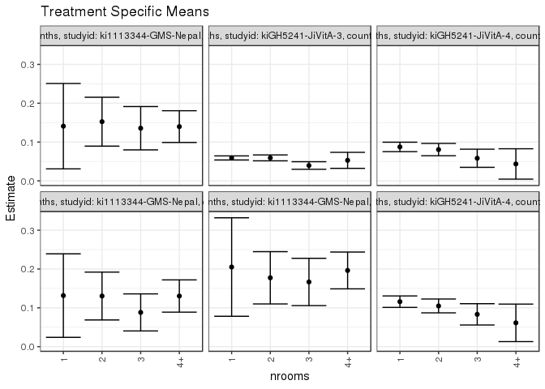

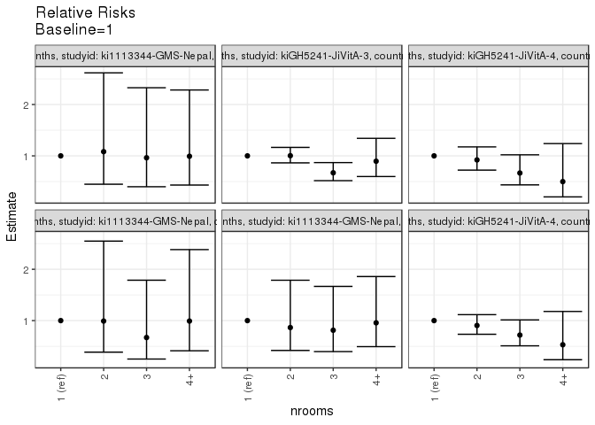

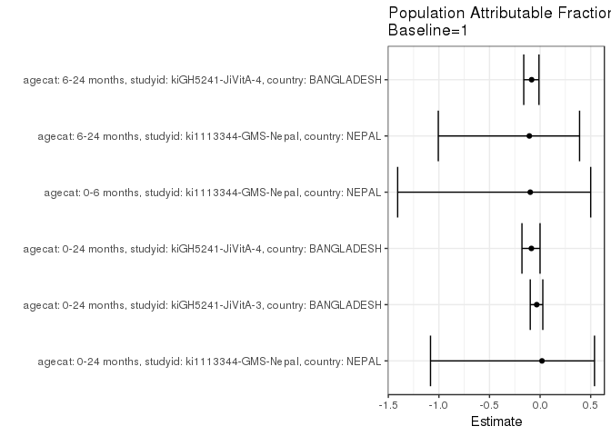

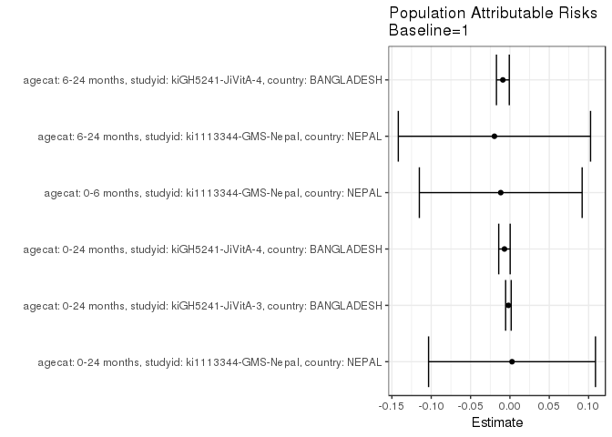

## Results Table

### Parameter: TSM

| agecat | studyid | country | intervention_level | baseline_level | estimate | ci_lower | ci_upper |
| --- | --- | --- | --- | --- | --- | --- | --- |
| 0-24 months | ki1113344-GMS-Nepal | NEPAL | 1 | NA | 0.1408952 | 0.0309386 | 0.2508518 |
| 0-24 months | ki1113344-GMS-Nepal | NEPAL | 2 | NA | 0.1524347 | 0.0894643 | 0.2154052 |
| 0-24 months | ki1113344-GMS-Nepal | NEPAL | 3 | NA | 0.1356571 | 0.0798445 | 0.1914697 |
| 0-24 months | ki1113344-GMS-Nepal | NEPAL | 4+ | NA | 0.1397904 | 0.0989297 | 0.1806510 |
| 0-24 months | kiGH5241-JiVitA-3 | BANGLADESH | 1 | NA | 0.0590911 | 0.0538457 | 0.0643365 |
| 0-24 months | kiGH5241-JiVitA-3 | BANGLADESH | 2 | NA | 0.0592806 | 0.0516895 | 0.0668717 |
| 0-24 months | kiGH5241-JiVitA-3 | BANGLADESH | 3 | NA | 0.0396017 | 0.0297940 | 0.0494094 |
| 0-24 months | kiGH5241-JiVitA-3 | BANGLADESH | 4+ | NA | 0.0529136 | 0.0322974 | 0.0735298 |
| 0-24 months | kiGH5241-JiVitA-4 | BANGLADESH | 1 | NA | 0.0875057 | 0.0753780 | 0.0996334 |
| 0-24 months | kiGH5241-JiVitA-4 | BANGLADESH | 2 | NA | 0.0806125 | 0.0647587 | 0.0964664 |
| 0-24 months | kiGH5241-JiVitA-4 | BANGLADESH | 3 | NA | 0.0582683 | 0.0349073 | 0.0816292 |
| 0-24 months | kiGH5241-JiVitA-4 | BANGLADESH | 4+ | NA | 0.0436034 | 0.0045027 | 0.0827042 |
| 0-6 months | ki1113344-GMS-Nepal | NEPAL | 1 | NA | 0.1315789 | 0.0240029 | 0.2391550 |
| 0-6 months | ki1113344-GMS-Nepal | NEPAL | 2 | NA | 0.1304348 | 0.0688252 | 0.1920443 |
| 0-6 months | ki1113344-GMS-Nepal | NEPAL | 3 | NA | 0.0882353 | 0.0405217 | 0.1359489 |
| 0-6 months | ki1113344-GMS-Nepal | NEPAL | 4+ | NA | 0.1304348 | 0.0888976 | 0.1719719 |
| 6-24 months | ki1113344-GMS-Nepal | NEPAL | 1 | NA | 0.2051282 | 0.0782889 | 0.3319675 |
| 6-24 months | ki1113344-GMS-Nepal | NEPAL | 2 | NA | 0.1774194 | 0.1101211 | 0.2447176 |
| 6-24 months | ki1113344-GMS-Nepal | NEPAL | 3 | NA | 0.1666667 | 0.1057442 | 0.2275891 |
| 6-24 months | ki1113344-GMS-Nepal | NEPAL | 4+ | NA | 0.1962963 | 0.1488779 | 0.2437147 |
| 6-24 months | kiGH5241-JiVitA-4 | BANGLADESH | 1 | NA | 0.1159116 | 0.1011868 | 0.1306364 |
| 6-24 months | kiGH5241-JiVitA-4 | BANGLADESH | 2 | NA | 0.1049111 | 0.0870956 | 0.1227265 |
| 6-24 months | kiGH5241-JiVitA-4 | BANGLADESH | 3 | NA | 0.0832771 | 0.0558484 | 0.1107057 |
| 6-24 months | kiGH5241-JiVitA-4 | BANGLADESH | 4+ | NA | 0.0614232 | 0.0131421 | 0.1097044 |

### Parameter: E(Y)

| agecat | studyid | country | intervention_level | baseline_level | estimate | ci_lower | ci_upper |
| --- | --- | --- | --- | --- | --- | --- | --- |
| 0-24 months | ki1113344-GMS-Nepal | NEPAL | NA | NA | 0.1435811 | 0.1153098 | 0.1718524 |
| 0-24 months | kiGH5241-JiVitA-3 | BANGLADESH | NA | NA | 0.0571830 | 0.0530902 | 0.0612758 |
| 0-24 months | kiGH5241-JiVitA-4 | BANGLADESH | NA | NA | 0.0805591 | 0.0719065 | 0.0892117 |
| 0-6 months | ki1113344-GMS-Nepal | NEPAL | NA | NA | 0.1199262 | 0.0925504 | 0.1473020 |
| 6-24 months | ki1113344-GMS-Nepal | NEPAL | NA | NA | 0.1854419 | 0.1537023 | 0.2171816 |
| 6-24 months | kiGH5241-JiVitA-4 | BANGLADESH | NA | NA | 0.1069508 | 0.0962252 | 0.1176764 |

### Parameter: RR

| agecat | studyid | country | intervention_level | baseline_level | estimate | ci_lower | ci_upper |
| --- | --- | --- | --- | --- | --- | --- | --- |
| 0-24 months | ki1113344-GMS-Nepal | NEPAL | 1 | 1 | 1.0000000 | 1.0000000 | 1.0000000 |
| 0-24 months | ki1113344-GMS-Nepal | NEPAL | 2 | 1 | 1.0819014 | 0.4473664 | 2.6164476 |
| 0-24 months | ki1113344-GMS-Nepal | NEPAL | 3 | 1 | 0.9628224 | 0.3984369 | 2.3266595 |
| 0-24 months | ki1113344-GMS-Nepal | NEPAL | 4+ | 1 | 0.9921582 | 0.4311540 | 2.2831240 |
| 0-24 months | kiGH5241-JiVitA-3 | BANGLADESH | 1 | 1 | 1.0000000 | 1.0000000 | 1.0000000 |
| 0-24 months | kiGH5241-JiVitA-3 | BANGLADESH | 2 | 1 | 1.0032071 | 0.8638061 | 1.1651047 |
| 0-24 months | kiGH5241-JiVitA-3 | BANGLADESH | 3 | 1 | 0.6701807 | 0.5169879 | 0.8687673 |
| 0-24 months | kiGH5241-JiVitA-3 | BANGLADESH | 4+ | 1 | 0.8954583 | 0.5977654 | 1.3414052 |
| 0-24 months | kiGH5241-JiVitA-4 | BANGLADESH | 1 | 1 | 1.0000000 | 1.0000000 | 1.0000000 |
| 0-24 months | kiGH5241-JiVitA-4 | BANGLADESH | 2 | 1 | 0.9212260 | 0.7223474 | 1.1748604 |
| 0-24 months | kiGH5241-JiVitA-4 | BANGLADESH | 3 | 1 | 0.6658795 | 0.4346105 | 1.0202133 |
| 0-24 months | kiGH5241-JiVitA-4 | BANGLADESH | 4+ | 1 | 0.4982923 | 0.2004130 | 1.2389178 |
| 0-6 months | ki1113344-GMS-Nepal | NEPAL | 1 | 1 | 1.0000000 | 1.0000000 | 1.0000000 |
| 0-6 months | ki1113344-GMS-Nepal | NEPAL | 2 | 1 | 0.9913043 | 0.3856030 | 2.5484357 |
| 0-6 months | ki1113344-GMS-Nepal | NEPAL | 3 | 1 | 0.6705882 | 0.2516216 | 1.7871624 |
| 0-6 months | ki1113344-GMS-Nepal | NEPAL | 4+ | 1 | 0.9913043 | 0.4122431 | 2.3837494 |
| 6-24 months | ki1113344-GMS-Nepal | NEPAL | 1 | 1 | 1.0000000 | 1.0000000 | 1.0000000 |
| 6-24 months | ki1113344-GMS-Nepal | NEPAL | 2 | 1 | 0.8649194 | 0.4187277 | 1.7865681 |
| 6-24 months | ki1113344-GMS-Nepal | NEPAL | 3 | 1 | 0.8125000 | 0.3961573 | 1.6663995 |
| 6-24 months | ki1113344-GMS-Nepal | NEPAL | 4+ | 1 | 0.9569444 | 0.4926963 | 1.8586351 |
| 6-24 months | kiGH5241-JiVitA-4 | BANGLADESH | 1 | 1 | 1.0000000 | 1.0000000 | 1.0000000 |
| 6-24 months | kiGH5241-JiVitA-4 | BANGLADESH | 2 | 1 | 0.9050957 | 0.7340370 | 1.1160175 |
| 6-24 months | kiGH5241-JiVitA-4 | BANGLADESH | 3 | 1 | 0.7184535 | 0.5090008 | 1.0140955 |
| 6-24 months | kiGH5241-JiVitA-4 | BANGLADESH | 4+ | 1 | 0.5299146 | 0.2382828 | 1.1784714 |

### Parameter: PAR

| agecat | studyid | country | intervention_level | baseline_level | estimate | ci_lower | ci_upper |
| --- | --- | --- | --- | --- | --- | --- | --- |
| 0-24 months | ki1113344-GMS-Nepal | NEPAL | 1 | NA | 0.0026859 | -0.1033661 | 0.1087378 |
| 0-24 months | kiGH5241-JiVitA-3 | BANGLADESH | 1 | NA | -0.0019081 | -0.0054442 | 0.0016279 |
| 0-24 months | kiGH5241-JiVitA-4 | BANGLADESH | 1 | NA | -0.0069467 | -0.0142180 | 0.0003247 |
| 0-6 months | ki1113344-GMS-Nepal | NEPAL | 1 | NA | -0.0116527 | -0.1150902 | 0.0917847 |
| 6-24 months | ki1113344-GMS-Nepal | NEPAL | 1 | NA | -0.0196863 | -0.1418369 | 0.1024643 |
| 6-24 months | kiGH5241-JiVitA-4 | BANGLADESH | 1 | NA | -0.0089608 | -0.0171238 | -0.0007978 |

### Parameter: PAF

| agecat | studyid | country | intervention_level | baseline_level | estimate | ci_lower | ci_upper |
| --- | --- | --- | --- | --- | --- | --- | --- |
| 0-24 months | ki1113344-GMS-Nepal | NEPAL | 1 | NA | 0.0187062 | -1.0830947 | 0.5377370 |
| 0-24 months | kiGH5241-JiVitA-3 | BANGLADESH | 1 | NA | -0.0333689 | -0.0972950 | 0.0268330 |
| 0-24 months | kiGH5241-JiVitA-4 | BANGLADESH | 1 | NA | -0.0862305 | -0.1793130 | -0.0004951 |
| 0-6 months | ki1113344-GMS-Nepal | NEPAL | 1 | NA | -0.0971660 | -1.4077031 | 0.5000325 |
| 6-24 months | ki1113344-GMS-Nepal | NEPAL | 1 | NA | -0.1061586 | -1.0062454 | 0.3901110 |
| 6-24 months | kiGH5241-JiVitA-4 | BANGLADESH | 1 | NA | -0.0837843 | -0.1615372 | -0.0112361 |